# Analyzing WeRateDogs Twitter Data

## Introduction

WeRateDogs is a Twitter account that rates people's dogs with a humorous comment about the dog, which has over 4 million followers and has received international media coverage. These ratings used by this account almost always have a denominator of 10, and the numerators almost always greater than the denominators. This unique rating system is a big part of the popularity of WeRateDogs.

In this project, I wrangled WeRateDogs Twitter data to create interesting and trustworthy analyses and visualizations. While investigating and analyzing the wrangled dataset, I will be answering the following questions:

- How the dog ratings in this twitter account are distributed?
- How the dog ratings are distributed based on dog stages?
- Is there a relationship between dog ratings and favorites & retweets Count?

The answers to these three questions could be useful to understand the characteristics of tweets that receives high dogs ratings and how twitter users interact with such tweets.

### Insight (1): The Distribution of Ratings

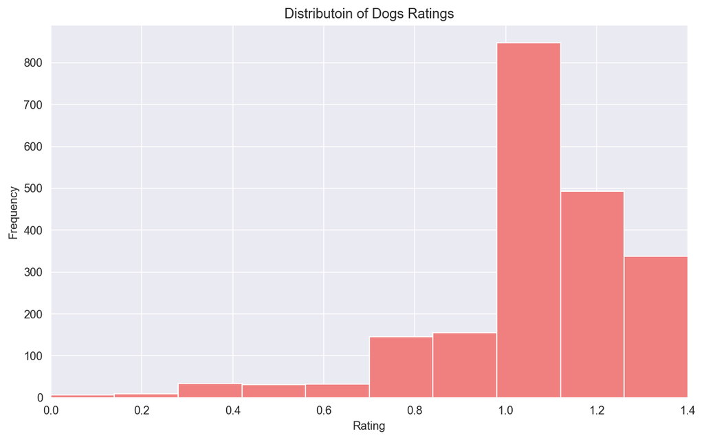

From the above histogram, we can find that in general, more than 50 percent of the tweets received ratings with numerators greater than the denominators. This could give us a clue that the majority of dogs are getting high ratings by this account.

### Insight (2): Distribution of Ratings based on Dog Stage

Before diving deeper in concluding which dog stage is getting the higher ratings, let us understand how the tweets counts are distributed among these stages.

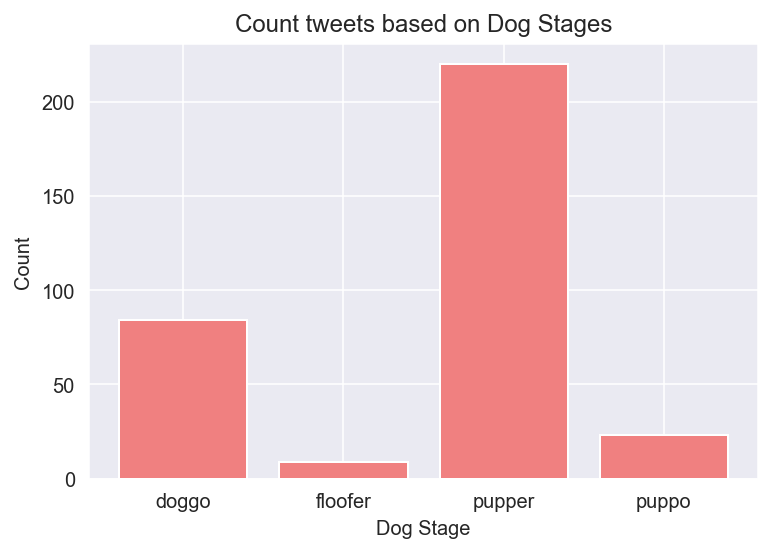

From the bar chart, we can find that dogs in 'pupper' stage are the ones securing the majority of these tweet counts in which more than 200 tweets, taking into consideration that there are only 336 records in the dataset out of 2089 which has extracted dog stage.

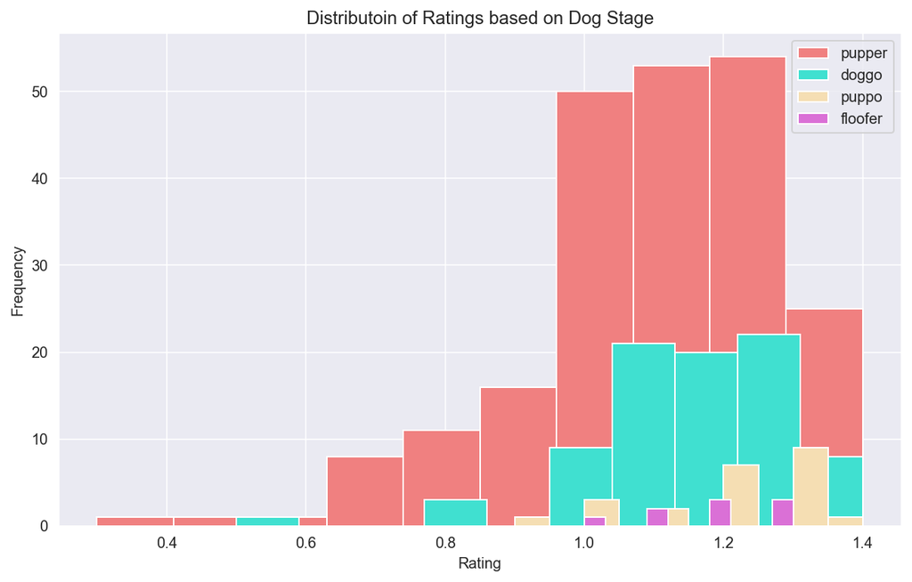

As the above bar chart shows, it is clear that the majority of tweets for each dog stage is getting ratings higher than 10 (or we can say ratings with numerators greater than the denominators as some ratings are out of scales different than 10). Which leads us to the conclusion that receiving a high dog rating is not biased by the dog stage.

### Insight (3): The Relation between Dog Ratings and Favorites & Retweets Count

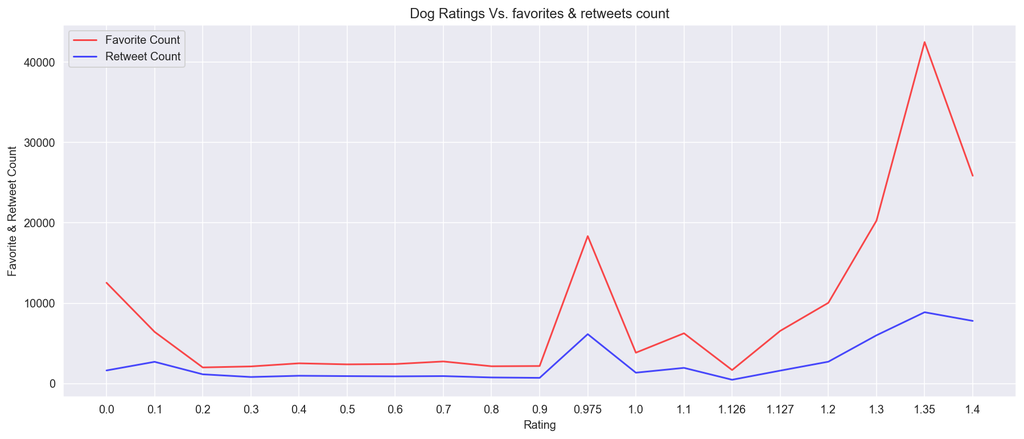